# 11_machine_learning_take2

Julin Maloof

01/21/2021

The goal of this file is to find which WGCNA modules are best able to predict leaf length.

Here I modify the original script to use a multi-CV approach that I developed from the metabolites.

```r
library(glmnet)
library(relaimpo)
library(tidyverse)
```

## get data

leafdata

```r
leaf <- read_csv("../../plant/output/leaf_lengths_combined.csv") %>%
  mutate(sampleID=str_remove(sampleID, "_(leaf|root)"),
         sampleID=str_remove(sampleID, "^[a-h][1-8]_")) %>%
  filter(!duplicated(sampleID))
leaf %>% arrange(sampleID)
```

| sampleID | fullname | exp | pot | soil | tissue | genotype | autoclave | leaf_avg | group | leaf_avg_std | leaf_avg_resid |
| --- | --- | --- | --- | --- | --- | --- | --- | --- | --- | --- | --- |
| 5e_dead_cr_12_a228 | g3_5e_dead_cr_12_a228_S51 | exp_density | A228 | 5E | root | FPsc | dead | 4.516667 | exp_density_FPsc | -0.73847596 | -0.23750000 |
| 5e_dead_cr_12_a235 | g6_5e_dead_cr_12_a235_S54 | exp_density | A235 | 5E | root | FPsc | dead | 4.700000 | exp_density_FPsc | -0.16842434 | -0.05416667 |
| 5e_dead_cr_3_a44 | a2_5e_dead_cr_3_a44_S2 | exp_density | A44 | 5E | root | FPsc | dead | 4.433333 | exp_density_FPsc | -0.99759034 | -0.32083333 |
| 5e_dead_cr_3_a54 | a5_5e_dead_cr_3_a54_S5 | exp_density | A54 | 5E | root | FPsc | dead | 4.933333 | exp_density_FPsc | 0.55709590 | 0.17916667 |
| 5e_dead_cr_6_a104 | c2_5e_dead_cr_6_a104_S18 | exp_density | A104 | 5E | root | FPsc | dead | 4.616667 | exp_density_FPsc | -0.42753872 | -0.13750000 |
| 5e_dead_cr_6_a119 | c7_5e_dead_cr_6_a119_S23 | exp_density | A119 | 5E | root | FPsc | dead | 4.266667 | exp_density_FPsc | -1.51581908 | -0.48750000 |
| 5e_dead_cr_8_a142 | e1_5e_dead_cr_8_a142_S33 | exp_density | A142 | 5E | root | FPsc | dead | 4.066667 | exp_density_FPsc | -2.13769358 | -0.68750000 |
| 5e_dead_cr_8_a153 | e6_5e_dead_cr_8_a153_S38 | exp_density | A153 | 5E | root | FPsc | dead | 4.875000 | exp_density_FPsc | 0.37571584 | 0.12083333 |
| 5e_live_cr_12_a236 | g7_5e_live_cr_12_a236_S55 | exp_density | A236 | 5E | root | FPsc | live | 5.225000 | exp_density_FPsc | 1.46399621 | 0.47083333 |
| 5e_live_cr_12_a240 | g8_5e_live_cr_12_a240_S56 | exp_density | A240 | 5E | root | FPsc | live | 4.700000 | exp_density_FPsc | -0.16842434 | -0.05416667 |

[output cut: 42 more lines]

load root modules

```r
root.voom5 <- readr::read_tsv(file.path("..","output","voom_expression.e1and3.resid.exp_gt.root.plusR500.txt.gz"))
load("../output/voom_expression.e1and3.resid.exp_gt.root.plusR500.signedhybrid.txt.gz.WGCNA.softthresh10.signedhybrid.RData")

rootMEs <- MEs %>% as_tibble() %>%
  rename_all(str_c, "_root") %>%
  mutate(sampleID=colnames(root.voom5)[-1],
         sampleID=str_remove(sampleID, "_root"),
         sampleID=str_remove(sampleID, "_S[0-9]{1,3}$"),
         sampleID=str_remove(sampleID, "^[a-h][1-8]_")) %>%
  select(sampleID, everything())
rootMEs
```

| sampleID | MEturquoise_root | MEblack_root | MEpaleturquoise_root | MElightsteelblue1_root | MEivory_root | MEbrown_root | MEdarkgrey_root | MEdarkorange2_root | MEdarkgreen_root | MEskyblue_root | MEplum1_root | MEbisque4_root | MEblue_root | MEorange_root | MEgreen_root | MEorangered4_root | MEdarkslateblue_root | MEfloralwhite_root | MEgreenyellow_root | MEmagenta_root | MEcyan_root | MEdarkmagenta_root | MEdarkred_root | MEgrey60_root | MEgrey_root |
| --- | --- | --- | --- | --- | --- | --- | --- | --- | --- | --- | --- | --- | --- | --- | --- | --- | --- | --- | --- | --- | --- | --- | --- | --- | --- |
| wyo_FPsc_02_052 | -0.3962347572 | -0.120657102 | -0.085987686 | -0.104016755 | -0.039959822 | 0.2131532479 | 0.321878083 | -0.053418886 | 0.18884075 | 0.178156449 | 0.369647289 | 0.089019334 | 0.360994637 | -0.019409737 | 0.270259368 | 0.068390570 | 0.015255406 | -0.025835137 | 3.301739e-01 | 0.212822199 | -0.37161197 | -0.29026896 | -0.209749934 | 0.08571573 | -0.138344539 |
| wyo_FPsc_02_064 | -0.1895256692 | -0.232831043 | -0.229860012 | 0.008375981 | 0.062394504 | -0.0331195704 | 0.043247907 | 0.086242254 | 0.05905616 | -0.071574173 | 0.214409462 | 0.269500327 | 0.144025515 | 0.088127170 | -0.081649030 | -0.010808106 | -0.097631556 | -0.191580251 | 1.141078e-01 | 0.118302402 | 0.04787186 | -0.04018458 | -0.032945565 | 0.18063743 | 0.076265788 |
| wyo_FPsc_04_141 | 0.1665015450 | 0.182799473 | 0.102498749 | 0.085401529 | 0.115782271 | 0.0674813218 | -0.008429248 | -0.004073776 | -0.28023596 | -0.054658313 | -0.155892535 | -0.023240987 | -0.067569558 | 0.005492199 | -0.153049784 | -0.569663527 | 0.141464728 | 0.156187624 | -4.108498e-02 | 0.008695997 | 0.13503899 | 0.01258067 | -0.149631826 | -0.18020677 | 0.034755801 |
| wyo_FPsc_04_174 | 0.1849426961 | 0.010478514 | -0.056829621 | -0.147560211 | -0.145557293 | -0.1486116857 | -0.196610471 | -0.198468587 | -0.10380172 | -0.144577694 | -0.186942180 | -0.141627960 | -0.145845421 | 0.211505855 | 0.136413279 | 0.036347504 | 0.189755074 | 0.132589682 | -7.216658e-02 | 0.042590218 | 0.05593211 | 0.27969179 | 0.118575961 | -0.08808119 | 0.085727431 |
| wyo_FPsc_05_181 | -0.2841573398 | 0.020269123 | -0.169068160 | 0.040095965 | 0.152932835 | 0.2165997781 | 0.337514748 | -0.025072365 | -0.05172401 | -0.079661268 | 0.078832600 | 0.077041470 | 0.242896740 | -0.128474544 | -0.310144127 | -0.147945262 | -0.005189993 | -0.046651929 | 2.119326e-01 | 0.188734347 | 0.11462183 | -0.11089472 | -0.189221606 | 0.10726690 | -0.068595830 |
| wyo_FPsc_05_218 | 0.1580550480 | 0.114000082 | 0.146949887 | 0.065447653 | -0.167822468 | -0.0172518653 | -0.149859682 | -0.029103817 | -0.14525136 | 0.025755276 | -0.061455262 | -0.251617761 | -0.095320399 | 0.064720484 | 0.189513706 | 0.154293463 | 0.005197037 | 0.046311793 | -2.165625e-01 | -0.133659496 | 0.09925169 | 0.03779454 | -0.048471996 | -0.22394948 | -0.036045554 |
| wyo_FPsc_07_272 | 0.1138728728 | 0.118299260 | 0.044268771 | 0.052941594 | 0.043805595 | 0.0143859601 | 0.004372383 | 0.095501468 | -0.12720053 | -0.115611429 | -0.049469510 | 0.025849072 | -0.099740274 | 0.172812840 | 0.024199384 | -0.183212673 | 0.023181344 | 0.071312090 | 5.220429e-03 | -0.061335080 | 0.07377242 | 0.08629811 | -0.019236216 | -0.04532981 | 0.041895637 |
| wyo_FPsc_07_292 | 0.0962070704 | 0.097292945 | 0.066908395 | 0.064128237 | 0.094140765 | 0.0127006313 | -0.001702060 | 0.050334590 | -0.03891192 | 0.002603578 | -0.086597431 | -0.127578074 | -0.057556706 | -0.217214951 | -0.249508171 | -0.035218780 | 0.027797989 | 0.053267067 | -6.963475e-02 | -0.058275878 | 0.13679241 | -0.05050708 | -0.050600899 | -0.05816175 | -0.023010571 |
| wyo_FPsc_10_399 | 0.1018533239 | 0.032211055 | -0.031578810 | 0.011988652 | -0.160260913 | -0.0673156737 | -0.105586665 | -0.182645918 | 0.03321500 | 0.003499862 | -0.298301083 | -0.118081147 | -0.085448950 | -0.067580007 | -0.171722539 | -0.013680060 | 0.029069634 | -0.020753164 | -1.925574e-01 | -0.073838541 | 0.07233306 | 0.04135801 | 0.139372526 | 0.01777980 | 0.029561642 |
| wyo_FPsc_10_428 | -0.0334602721 | -0.040691107 | 0.060559872 | 0.092663010 | 0.087142375 | -0.0001724544 | -0.041949153 | 0.116392017 | 0.15606710 | 0.131679969 | 0.134860914 | 0.065753286 | 0.003588052 | -0.074609121 | 0.037892070 | 0.101895869 | -0.221786681 | -0.122741353 | -5.189236e-02 | -0.124892043 | -0.14012127 | -0.13409747 | 0.063892877 | 0.08800871 | 0.006428977 |

[output cut: 30 more lines]

```r
rm(MEs)
```

load leaf modules

```r
leaf.voom5 <- readr::read_tsv(file.path("..","output","voom_expression.e1and3.resid.exp_gt.leaf.plusR500.txt.gz"))
load(file.path("..","output","voom_expression.e1and3.resid.exp_gt.leaf.plusR500.signedhybrid.txt.gz.WGCNA.softthresh10.signedhybrid.RData"))

leafMEs <- MEs %>% as_tibble() %>%
  rename_all(str_c, "_leaf") %>%
  mutate(sampleID=colnames(leaf.voom5)[-1],
         sampleID=str_remove(sampleID, "_leaf"),
         sampleID=str_remove(sampleID, "_S[0-9]{1,3}$"),
         sampleID=str_remove(sampleID, "^[a-h][1-8]_")) %>%
  select(sampleID, everything())
leafMEs
```

| sampleID | MEmediumorchid_leaf | MEcyan_leaf | MEdarkmagenta_leaf | MElightcyan1_leaf | MEdarkorange_leaf | MEorangered4_leaf | MEantiquewhite4_leaf | MEmaroon_leaf | MElightgreen_leaf | MEorange_leaf | MEdarkorange2_leaf | MEhoneydew1_leaf | MEbrown_leaf | MEcoral1_leaf | MEcoral2_leaf | MEplum2_leaf | MElavenderblush3_leaf | MEmediumpurple3_leaf | MEbrown4_leaf | MEnavajowhite2_leaf | MElightsteelblue1_leaf | MEpalevioletred3_leaf | MEplum1_leaf | MEskyblue1_leaf | MEthistle2_leaf | MEyellow4_leaf | MEthistle1_leaf | MEdarkgrey_leaf | MEbisque4_leaf | … |
| --- | --- | --- | --- | --- | --- | --- | --- | --- | --- | --- | --- | --- | --- | --- | --- | --- | --- | --- | --- | --- | --- | --- | --- | --- | --- | --- | --- | --- | --- | --- |
| wyo_FPsc_02_052 | -0.063834020 | -0.0161514334 | -0.024339134 | 0.021581600 | -0.027578401 | -0.001036617 | 0.0006988529 | 0.050082189 | -0.0008761173 | -1.754683e-02 | -0.0188258916 | 0.0656269446 | 0.10335725 | 0.129876471 | -0.042856140 | -0.0286159491 | -0.100526393 | 0.001450480 | -0.05642097 | 0.0250582735 | -0.11095308 | 0.099244638 | -0.029837258 | -0.184435192 | -0.157672645 | 0.180880538 | -0.0648176360 | -0.072645274 | 0.034212392 | … |
| wyo_FPsc_02_064 | 0.031366054 | 0.0223978446 | 0.005887006 | 0.107276559 | 0.035057043 | 0.014112665 | -0.0252041309 | 0.063738870 | 0.0195078627 | -1.137361e-02 | -0.0286434096 | 0.0688737498 | 0.11545710 | 0.089174938 | 0.042736536 | 0.1240782010 | 0.027871261 | 0.061662840 | -0.04047444 | 0.0073886753 | -0.19634268 | -0.053104176 | -0.111248843 | -0.006303187 | 0.175415462 | -0.046086956 | -0.0049415396 | -0.147973873 | -0.148105165 | … |
| wyo_FPsc_04_141 | -0.031627587 | -0.0619742014 | -0.002802761 | 0.059762835 | -0.008434020 | 0.036397298 | -0.0056884794 | 0.197520310 | 0.0129517003 | -1.974475e-02 | -0.0144868902 | 0.2372826883 | 0.29239149 | 0.305538828 | 0.024975550 | 0.0030712362 | -0.121096803 | -0.105647243 | -0.14170359 | -0.0014204871 | -0.28470477 | -0.117756242 | -0.100354077 | -0.285778947 | -0.254970938 | -0.190718197 | -0.1545672093 | -0.122093513 | -0.005358418 | … |
| wyo_FPsc_04_174 | -0.015310009 | -0.0092477383 | 0.013572078 | -0.010233146 | 0.002129339 | -0.009560730 | 0.0108426798 | 0.018401246 | 0.0013572548 | 4.033499e-03 | 0.0104985519 | 0.0434076705 | 0.02690758 | 0.038089049 | 0.008307280 | 0.0281043423 | 0.092604495 | 0.089539196 | -0.08817505 | 0.0210797450 | 0.03879710 | -0.014506556 | 0.008310585 | 0.099375122 | -0.007047809 | 0.025671543 | -0.0626295034 | 0.010960692 | -0.078985024 | … |
| wyo_FPsc_05_181 | -0.049385946 | -0.0085107776 | -0.026033726 | 0.040654410 | 0.006946327 | 0.022597212 | -0.0176800783 | 0.080986439 | -0.0031396666 | -1.113350e-02 | -0.0261784439 | 0.0717773848 | 0.10617965 | 0.116635141 | -0.007918788 | -0.0202578964 | -0.131687040 | -0.176564643 | 0.08157131 | -0.0331765605 | -0.21430208 | -0.041667854 | -0.066920347 | -0.258919538 | 0.108692733 | -0.102958843 | 0.0364660299 | -0.094467559 | 0.125465477 | … |
| wyo_FPsc_05_218 | 0.052598681 | 0.0310803743 | -0.009922224 | -0.031714961 | 0.006313731 | -0.016217360 | -0.0088942363 | -0.198816690 | -0.0229100826 | 1.039565e-02 | 0.0027034992 | -0.2456716583 | -0.25913812 | -0.319592995 | 0.044307544 | 0.0266679754 | 0.110395961 | 0.183019960 | 0.13796732 | -0.0079485371 | 0.20793481 | 0.129695534 | 0.034040414 | 0.167105478 | 0.466210102 | 0.013036420 | 0.0438972303 | 0.124434549 | 0.103259549 | … |
| wyo_FPsc_07_272 | -0.015734612 | -0.0134381451 | -0.005461665 | 0.026892479 | -0.017226344 | -0.023444052 | -0.0112153615 | 0.080793315 | 0.0002461163 | -1.198366e-02 | -0.0082175909 | 0.0803657319 | 0.08368935 | 0.090489992 | 0.001000459 | 0.0240895938 | -0.009828231 | -0.077974301 | -0.05226906 | -0.0351538188 | -0.02366427 | -0.037171851 | -0.016765323 | 0.096539347 | -0.196355049 | -0.111964263 | 0.0001620886 | -0.028007025 | -0.028601948 | … |
| wyo_FPsc_07_292 | -0.010546748 | -0.0023463409 | 0.016427531 | 0.009222848 | 0.027142446 | 0.028949586 | 0.0053854108 | 0.061719776 | 0.0127787649 | 1.978397e-02 | 0.0039861328 | 0.0663834365 | 0.09171153 | 0.117860323 | 0.001016968 | -0.0533531232 | -0.079803234 | -0.151130843 | 0.03972435 | -0.0201364201 | -0.07680746 | -0.063770182 | -0.016849724 | -0.153179895 | -0.188050594 | -0.062827252 | -0.0217177019 | -0.051005210 | -0.027185310 | … |
| wyo_FPsc_10_399 | 0.038213427 | 0.0433379773 | 0.026355808 | -0.085271914 | 0.027883618 | -0.002564914 | 0.0189578581 | -0.164173766 | -0.0042697599 | 3.320708e-02 | 0.0366579249 | -0.2008770221 | -0.24276413 | -0.250900231 | -0.017685137 | -0.0489543594 | 0.071091923 | 0.124448973 | 0.17846975 | 0.0034632515 | 0.21575659 | 0.030408521 | 0.106074848 | 0.211705033 | 0.254983434 | 0.245735370 | 0.0502298724 | 0.120447839 | 0.082601641 | … |
| wyo_FPsc_10_428 | 0.031078641 | 0.0052217324 | 0.004152628 | -0.004037760 | 0.043543783 | 0.036193328 | 0.0074203472 | 0.007332732 | 0.0096828983 | 1.248100e-02 | 0.0049189165 | -0.0178020326 | -0.01104772 | -0.020925793 | -0.003395297 | -0.0686000738 | -0.166363516 | -0.186998525 | 0.10123784 | 0.0217194910 | -0.03947265 | -0.030978523 | -0.025108307 | 0.077843135 | 0.078091477 | -0.084551434 | 0.0599188305 | -0.023339740 | 0.061453435 | … |

[output cut: 30 more lines]

```r
rm(MEs)
```

bring it all together

```r
d_with_trt <- leaf %>% select(sampleID, autoclave, leaf_avg_std) %>%
  inner_join(leafMEs, by="sampleID") %>%
  inner_join(rootMEs, by="sampleID") %>%
  as_data_frame() %>%
  select(-sampleID)

d <- d_with_trt %>% select(-soil, -autoclave)
```

[output not shown]

```r
apply(d, 2, mean)
```

```
          leaf_avg_std    MEmediumorchid_leaf            MEcyan_leaf     MEdarkmagenta_leaf      MElightcyan1_leaf      MEdarkorange_leaf
          1.358421e-01           2.775558e-18          -2.775558e-18           3.295975e-18           2.151057e-17           1.387779e-17
     MEorangered4_leaf   MEantiquewhite4_leaf          MEmaroon_leaf      MElightgreen_leaf          MEorange_leaf     MEdarkorange2_leaf
          1.665335e-17          -8.153200e-18           1.387779e-18          -2.636780e-17          -2.402592e-17           5.377643e-18
      MEhoneydew1_leaf           MEbrown_leaf          MEcoral1_leaf          MEcoral2_leaf           MEplum2_leaf  MElavenderblush3_leaf
          1.209970e-17           1.439820e-17           1.162265e-17          -6.938894e-18           2.636780e-17          -1.856154e-17
  MEmediumpurple3_leaf          MEbrown4_leaf    MEnavajowhite2_leaf MElightsteelblue1_leaf  MEpalevioletred3_leaf           MEplum1_leaf
         -6.201636e-18          -2.125036e-18           4.597017e-18          -1.804112e-17          -6.938894e-18          -1.214306e-17
       MEskyblue1_leaf        MEthistle2_leaf         MEyellow4_leaf        MEthistle1_leaf        MEdarkgrey_leaf         MEbisque4_leaf
         -3.851086e-17          -2.064321e-17           1.387779e-17          -2.775558e-18           1.526557e-17           3.885781e-17
  MEdarkseagreen4_leaf            MEgrey_leaf       MEturquoise_root           MEblack_root   MEpaleturquoise_root MElightsteelblue1_root
          1.110223e-17           6.938894e-17          -9.714451e-18           2.151057e-17          -1.318390e-17          -1.942890e-17
          MEivory_root           MEbrown_root        MEdarkgrey_root     MEdarkorange2_root       MEdarkgreen_root         MEskyblue_root
          1.387779e-18           8.673617e-18          -3.122502e-18          -5.551115e-18          -2.844947e-17          -1.439820e-17
          MEplum1_root         MEbisque4_root            MEblue_root          MEorange_root           MEgreen_root      MEorangered4_root
          5.204170e-18          -7.806256e-18          -2.567391e-17           5.828671e-17          -3.148523e-17          -4.926615e-17
  MEdarkslateblue_root     MEfloralwhite_root     MEgreenyellow_root         MEmagenta_root            MEcyan_root     MEdarkmagenta_root
         -1.110223e-17          -1.665335e-17           1.942890e-17           6.938894e-18          -4.857226e-17           0.000000e+00
        MEdarkred_root          MEgrey60_root            MEgrey_root
          4.857226e-18          -2.619432e-17          -1.346145e-16
```

```r
apply(d, 2, sd)
```

```
          leaf_avg_std    MEmediumorchid_leaf            MEcyan_leaf     MEdarkmagenta_leaf      MElightcyan1_leaf      MEdarkorange_leaf
             1.0790602              0.1601282              0.1601282              0.1601282              0.1601282              0.1601282
     MEorangered4_leaf   MEantiquewhite4_leaf          MEmaroon_leaf      MElightgreen_leaf          MEorange_leaf     MEdarkorange2_leaf
             0.1601282              0.1601282              0.1601282              0.1601282              0.1601282              0.1601282
      MEhoneydew1_leaf           MEbrown_leaf          MEcoral1_leaf          MEcoral2_leaf           MEplum2_leaf  MElavenderblush3_leaf
             0.1601282              0.1601282              0.1601282              0.1601282              0.1601282              0.1601282
  MEmediumpurple3_leaf          MEbrown4_leaf    MEnavajowhite2_leaf MElightsteelblue1_leaf  MEpalevioletred3_leaf           MEplum1_leaf
             0.1601282              0.1601282              0.1601282              0.1601282              0.1601282              0.1601282
       MEskyblue1_leaf        MEthistle2_leaf         MEyellow4_leaf        MEthistle1_leaf        MEdarkgrey_leaf         MEbisque4_leaf
             0.1601282              0.1601282              0.1601282              0.1601282              0.1601282              0.1601282
  MEdarkseagreen4_leaf            MEgrey_leaf       MEturquoise_root           MEblack_root   MEpaleturquoise_root MElightsteelblue1_root
             0.1601282              0.1601282              0.1601282              0.1601282              0.1601282              0.1601282
          MEivory_root           MEbrown_root        MEdarkgrey_root     MEdarkorange2_root       MEdarkgreen_root         MEskyblue_root
             0.1601282              0.1601282              0.1601282              0.1601282              0.1601282              0.1601282
          MEplum1_root         MEbisque4_root            MEblue_root          MEorange_root           MEgreen_root      MEorangered4_root
             0.1601282              0.1601282              0.1601282              0.1601282              0.1601282              0.1601282
  MEdarkslateblue_root     MEfloralwhite_root     MEgreenyellow_root         MEmagenta_root            MEcyan_root     MEdarkmagenta_root
             0.1601282              0.1601282              0.1601282              0.1601282              0.1601282              0.1601282
        MEdarkred_root          MEgrey60_root            MEgrey_root
             0.1601282              0.1601282              0.1601282
```

## elastic net regression

### Use a multi-cross validation to compare different alphas

With a small number of samples, there is a lot of run-to-run variation in cross validation attempts. I will do many and average over them to choose an appropriate alpha and lambda.

## multi CV

set up the data

```r
x <- d %>% select(starts_with("ME")) %>% as.matrix()
y <- d %>% pull(leaf_avg_std)
```

```r
set.seed(1245)

folds <- tibble(run=1:101) %>%
  mutate(folds=map(run, ~ sample(rep(1:5,8))))

system.time (multiCV <- expand_grid(run=1:100, alpha=seq(0,1,.1)) %>%
               left_join(folds, by="run") %>%
               mutate(fit=map2(folds, alpha, ~ cv.glmnet(x=x, y=y, foldid = .x, alpha=.y
                                                         )))
             #, lambda=exp(seq(-5,0,length.out = 50)) )))
) #100 seconds
```

```
   user  system elapsed
 20.054   0.330  31.410
```

```r
head(multiCV)
```

| run | alpha | folds | fit |
| --- | --- | --- | --- |
| 1 | 0.0 |  |  |
| 1 | 0.1 |  |  |
| 1 | 0.2 |  |  |
| 1 | 0.3 |  |  |
| 1 | 0.4 |  |  |
| 1 | 0.5 |  |  |

for each fit, pull out the mean cv error, lambda, min lambda, and 1se lambda

```r
multiCV <- multiCV %>%
  mutate(cvm=map(fit, magrittr::extract("cvm")),
         lambda=map(fit, magrittr::extract("lambda")),
         lambda.min=map_dbl(fit, magrittr::extract("lambda.min" )),
         lambda.1se=map_dbl(fit, magrittr::extract("lambda.1se")),
         nzero=map(fit, magrittr::extract("nzero"))
  )

head(multiCV)
```

| run | alpha | folds | fit | cvm | lambda | lambda.min | lambda.1se | nzero |
| --- | --- | --- | --- | --- | --- | --- | --- | --- |
| 1 | 0.0 |  |  |  |  | 6.1602423 | 52.3468709 |  |
| 1 | 0.1 |  |  |  |  | 0.7956259 | 3.6929683 |  |
| 1 | 0.2 |  |  |  |  | 0.5258853 | 1.9344059 |  |
| 1 | 0.3 |  |  |  |  | 0.4030935 | 1.3510094 |  |
| 1 | 0.4 |  |  |  |  | 0.3317960 | 1.0132570 |  |
| 1 | 0.5 |  |  |  |  | 0.2654368 | 0.8106056 |  |

now calculate the mean and sem of cvm and min,1se labmdas. These need to be done separately because of the way the grouping works

```r
summary_cvm <- multiCV %>% dplyr::select(-fit, -folds) %>%
  unnest(c(cvm, lambda)) %>%
  group_by(alpha, lambda) %>%
  summarize(meancvm=mean(cvm), sem=sd(cvm)/sqrt(n()), high=meancvm+sem, low=meancvm-sem)
summary_cvm
```

| alpha | lambda | meancvm | sem | high | low |
| --- | --- | --- | --- | --- | --- |
| 0.0 | 6.160242e+00 | 0.9379153 | 0.005563748 | 0.9434790 | 0.9323515 |
| 0.0 | 6.453567e+00 | 0.9397670 | 0.005534515 | 0.9453015 | 0.9342324 |
| 0.0 | 6.760858e+00 | 0.9418729 | 0.005495563 | 0.9473684 | 0.9363773 |
| 0.0 | 7.082782e+00 | 0.9438487 | 0.005449359 | 0.9492980 | 0.9383993 |
| 0.0 | 7.420034e+00 | 0.9455657 | 0.005391267 | 0.9509570 | 0.9401745 |
| 0.0 | 7.773344e+00 | 0.9470389 | 0.005320799 | 0.9523597 | 0.9417181 |
| 0.0 | 8.143478e+00 | 0.9482532 | 0.005223115 | 0.9534763 | 0.9430301 |
| 0.0 | 8.531236e+00 | 0.9495314 | 0.005113143 | 0.9546446 | 0.9444183 |
| 0.0 | 8.937457e+00 | 0.9509999 | 0.005007949 | 0.9560078 | 0.9459919 |
| 0.0 | 9.363021e+00 | 0.9526539 | 0.004907419 | 0.9575614 | 0.9477465 |

[output cut: 990 more lines]

```r
summary_lambda <- multiCV %>% dplyr::select(-fit, -folds, -cvm) %>%
  group_by(alpha) %>%
  summarize(
    lambda.min.sd=sd(lambda.min),
    lambda.min.mean=mean(lambda.min),
    #lambda.min.med=median(lambda.min),
    lambda.min.high=lambda.min.mean+lambda.min.sd,
    #lambda.min.low=lambda.min.mean-lambda.min.sem,
    #lambda.1se.sem=sd(lambda.1se)/sqrt(n()),
    lambda.1se.mean=mean(lambda.1se),
    #lambda.1se.med=median(lambda.1se),
    #lambda.1se.high=lambda.1se+lambda.1se.sem,
    #lambda.1se.low=lambda.1se-lambda.1se.sem,
    nzero=nzero[1],
    lambda=lambda[1]
  )

summary_lambda
```

| alpha | lambda.min.sd | lambda.min.mean | lambda.min.high | lambda.1se.mean | nzero | lambda |
| --- | --- | --- | --- | --- | --- | --- |
| 0.0 | 1.72208308 | 6.8362839 | 8.5583670 | 176.0664830 |  |  |
| 0.1 | 0.38886276 | 1.4765618 | 1.8654246 | 4.0321830 |  |  |
| 0.2 | 0.21695026 | 0.8682177 | 1.0851680 | 2.1201504 |  |  |
| 0.3 | 0.15153499 | 0.6162134 | 0.7677484 | 1.4483193 |  |  |
| 0.4 | 0.12238553 | 0.4763729 | 0.5987585 | 1.1094899 |  |  |
| 0.5 | 0.10626458 | 0.3826901 | 0.4889547 | 0.9005258 |  |  |
| 0.6 | 0.08992092 | 0.3259335 | 0.4158545 | 0.7567353 |  |  |
| 0.7 | 0.07893146 | 0.2828315 | 0.3617630 | 0.6533748 |  |  |
| 0.8 | 0.06971153 | 0.2496408 | 0.3193523 | 0.5777006 |  |  |
| 0.9 | 0.06328282 | 0.2220163 | 0.2852991 | 0.5186995 |  |  |

[output cut: 1 more lines]

plot it

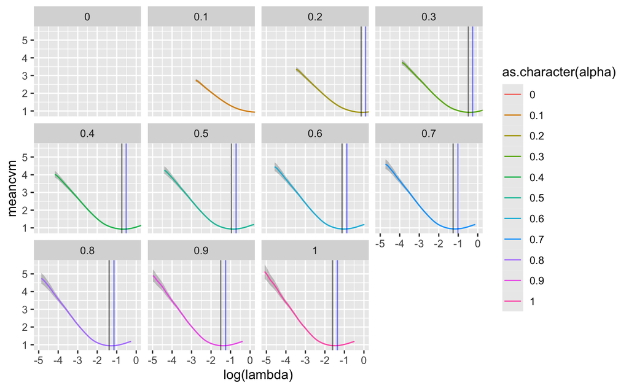

```r
summary_cvm %>%
  #filter(alpha!=0) %>% # worse than everything else and throwing the plots off
  ggplot(aes(x=log(lambda), y= meancvm,  ymin=low, ymax=high)) +
  geom_ribbon(alpha=.25) +
  geom_line(aes(color=as.character(alpha))) +
  facet_wrap(~ as.character(alpha)) +
   coord_cartesian(xlim=(c(-5,0))) +
  geom_vline(aes(xintercept=log(lambda.min.mean)), alpha=.5, data=summary_lambda) +
  geom_vline(aes(xintercept=log(lambda.min.high)), alpha=.5, data=summary_lambda, color="blue")
```

Min MSE per alpha:

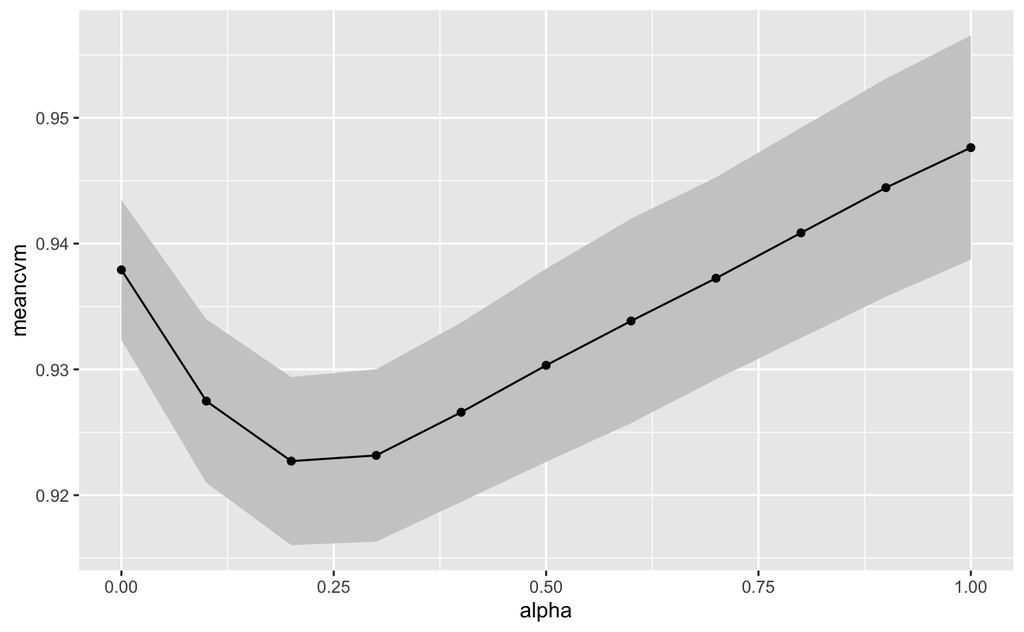

```r
summary_cvm %>%
  group_by(as.factor(alpha)) %>%
  filter(rank(meancvm, ties.method="first")==1) %>%
  ggplot(aes(x=alpha,y=meancvm,ymin=low,ymax=high)) +
  geom_ribbon(color=NA, fill="gray80") +
  geom_line() +
  geom_point()
```

Not a huge amount of difference there, but 0.2 or 0.3 are best.

Make a plot of number of nzero coefficients

[figure not shown]

```r
summary_lambda %>%
  unnest(c(lambda, nzero)) %>%
  group_by(alpha) %>%
  filter(abs(lambda.min.mean-lambda)==min(abs(lambda.min.mean-lambda))  ) %>%
  ungroup() %>%

ggplot(aes(x=as.character(alpha), y=nzero)) +
  geom_point() +
  ggtitle("Number of non-zero coefficents at minimum lambda") +
  ylim(0,24)
```

Choose alpha = .3

Look at the actual fit

```r
fit
```

```
Call:  cv.glmnet(x = x, y = y, foldid = .x, alpha = .y)

Measure: Mean-Squared Error

    Lambda Index Measure     SE Nonzero
min 0.4031    36  0.8923 0.1745      11
1se 1.3510    10  1.0639 0.1559       4
```

```r
multiCV_coef.tb <- coef(fit, s=bestlam_multiCV) %>%
  as.matrix() %>% as.data.frame() %>%
  rownames_to_column(var="ME") %>%
  dplyr::rename(beta_multiCV=`s1`)

multiCV_coef.tb %>% filter(beta_multiCV!=0) %>% arrange(beta_multiCV)
```

| ME | beta_multiCV |
| --- | --- |
| MEivory_root | -0.960746405 |
| MEhoneydew1_leaf | -0.469505360 |
| MElightcyan1_leaf | -0.444968591 |
| MEcoral1_leaf | -0.134706413 |
| MEmaroon_leaf | -0.037624910 |
| MEantiquewhite4_leaf | -0.015548362 |
| MEbisque4_root | -0.004671523 |
| (Intercept) | 0.135842073 |
| MEorangered4_root | 0.426531420 |
| MEdarkgrey_leaf | 0.643371506 |

[output cut: 1 more lines]

```r
NA
```

pred and obs

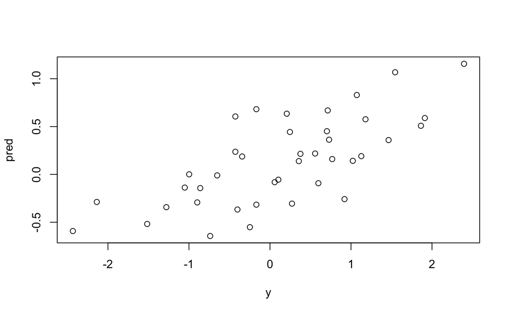

```r
pred <- predict(fit, s=bestlam_multiCV, newx=x)
plot(y,pred)
```

```r
cor.test(y, pred) #.71
```

```
    Pearson's product-moment correlation

data:  y and pred
t = 6.2097, df = 38, p-value = 2.936e-07
alternative hypothesis: true correlation is not equal to 0
95 percent confidence interval:
 0.5111948 0.8363126
sample estimates:
      cor
0.7096915
```

```r
mean((y-pred)^2) #0.66
```

```
[1] 0.6578165
```

check some train/test

```r
testtrain_multiCV <- tibble(run=1:10000) %>%
  mutate(train=map(run, ~ sample(1:40,8))) %>%
  mutate(fit=map(train, ~ glmnet(x=x[.,], y=y[.], lambda = bestlam_multiCV,
                                 alpha = .3 ) )) %>%
  mutate(pred=map2(fit, train, ~ predict(.x, newx = x[-.y,]))) %>%
  mutate(cor=map2_dbl(pred, train, ~ cor(.x, y[-.y])  )) %>%
  mutate(MSE=map2_dbl(pred, train, ~ mean((y[-.y] - .x)^2)))
sum(testtrain_multiCV$cor<=0, na.rm = TRUE) + sum(is.na(testtrain_multiCV$cor))
```

```
[1] 968
```

```r
mean(testtrain_multiCV$cor, na.rm=TRUE)
```

```
[1] 0.2750538
```

```r
mean(testtrain_multiCV$cor^2, na.rm=TRUE)
```

```
[1] 0.1134827
```

```r
mean(testtrain_multiCV$MSE)
```

```
[1] 1.611722
```

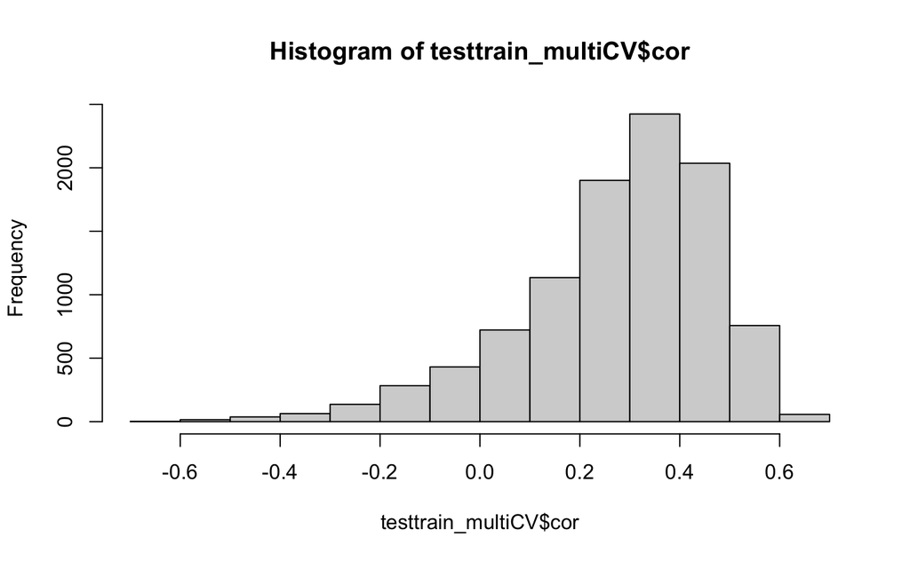

```r
hist(testtrain_multiCV$cor)
```

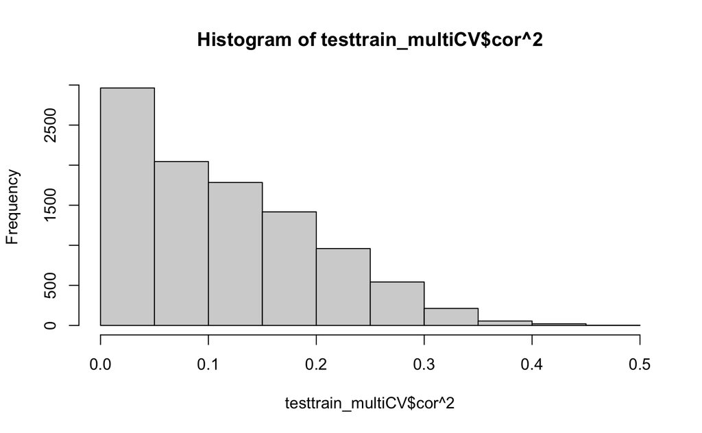

```r
hist(testtrain_multiCV$cor^2)
```

```r
t.test(testtrain_multiCV$cor)
```

```
    One Sample t-test

data:  testtrain_multiCV$cor
t = 141.41, df = 9998, p-value < 2.2e-16
alternative hypothesis: true mean is not equal to 0
95 percent confidence interval:
 0.2712409 0.2788666
sample estimates:
mean of x
0.2750538
```

```r
relimpmultiCV
```

```
Response variable: leaf_avg_std
Total response variance: 1.164371
Analysis based on 40 observations

10 Regressors:
MElightcyan1_leaf MEantiquewhite4_leaf MEmaroon_leaf MEhoneydew1_leaf MEcoral1_leaf MEdarkgrey_leaf MEivory_root MEbisque4_root MEorangered4_root MEdarkred_root
Proportion of variance explained by model: 61.47%
Metrics are not normalized (rela=FALSE).

Relative importance metrics:

                            lmg
MElightcyan1_leaf    0.07119225
MEantiquewhite4_leaf 0.04521431
MEmaroon_leaf        0.03470205
MEhoneydew1_leaf     0.03866743
MEcoral1_leaf        0.04146882
MEdarkgrey_leaf      0.06776611
MEivory_root         0.10302428
MEbisque4_root       0.04127151
MEorangered4_root    0.07520185
MEdarkred_root       0.09617642

Average coefficients for different model sizes:

                            1X        2Xs       3Xs        4Xs        5Xs        6Xs        7Xs        8Xs        9Xs      10Xs
MElightcyan1_leaf    -3.781945 -2.9432661 -2.344121 -1.9048220 -1.5497250 -1.2328638 -0.9660835 -0.8632382 -1.1952500 -2.454106
MEantiquewhite4_leaf -1.199928 -0.9560643 -1.018339 -1.2025995 -1.4438983 -1.7298045 -2.0749723 -2.5325234 -3.1859794 -4.128002
MEmaroon_leaf        -2.700824 -1.8077835 -1.150874 -0.6331251 -0.1953207  0.2048052  0.6116362  1.0997090  1.7742334  2.758973
MEhoneydew1_leaf     -2.705084 -1.9729344 -1.596515 -1.3905075 -1.2222326 -1.0171935 -0.7306398 -0.3053249  0.3345996  1.271211
MEcoral1_leaf        -3.031817 -2.1088690 -1.457045 -1.0216442 -0.7600555 -0.6509428 -0.7085686 -1.0172727 -1.7393372 -3.114249
MEdarkgrey_leaf       3.849646  3.0932379  2.362154  1.7202554  1.1936679  0.7691176  0.3780780 -0.1428125 -1.0822335 -2.875746
MEivory_root         -3.896079 -3.2031001 -2.777578 -2.5099558 -2.3377063 -2.2325725 -2.1786996 -2.1550392 -2.1099212 -1.921302
MEbisque4_root       -2.234698 -1.5421526 -1.231512 -1.1138585 -1.0965446 -1.1440198 -1.2447700 -1.4079489 -1.6520812 -1.983147
MEorangered4_root     2.811865  2.2527262  1.983557  1.8538866  1.7897367  1.7618009  1.7627444  1.8094015  1.9462335  2.246020
MEdarkred_root        3.694850  2.9723788  2.561561  2.3303052  2.2058091  2.1540177  2.1570427  2.1969772  2.2299405  2.155638
```

```r
d %>% ggplot(aes(x=MEivory_root, y=leaf_avg_std)) +
  geom_point()
```

[output not shown]

```r
d.plot <- d %>% dplyr::select(all_of(vars)) %>%
  pivot_longer(cols = !leaf_avg_std, names_to = "module", values_to ="eigenGene") %>%
  mutate(module=str_remove(module,"ME")) %>%
  mutate(module=str_replace(module, "(.*)_(leaf|root)","\\2: \\1"))

d.plot.order <- d.plot %>%
  group_by(module) %>%
  summarize(cor=abs(cor(leaf_avg_std, eigenGene))) %>%
  arrange(desc(cor)) %>%
  pull(module)

d.plot %>%
  mutate(module=factor(module, levels= d.plot.order)) %>%
  ggplot(aes(x=eigenGene, y=leaf_avg_std)) +
  geom_point() +
  facet_wrap(~module, ncol = 3, scales = "free") +
  theme_bw() +
  ylab("Standardized Leaf Length") +
  xlab("Eigen Gene Expression")
ggsave("../../_Paper_Figures/Eigen_leaf_length.pdf", height=6, width=6)

ggsave("/Volumes/GoogleDrive/Shared drives/BrassicaMicrobeRNAseq/Figs and Tables/Fig4_Eigen_leaf_length.png", height=7, width=6)
```

[output not shown]